# Assignment_2

## E1:

Given the dataset "ap" below,

1. use the ap.describe() to get the basic statistics, print the result.
2. Explain the meaning of "count", "mean", "std", "min", "25\%", in the result.
3. Plot the histogram of "wkd_day_value", i.e. ap["wkd_day_value"], is it skewed?
4. Write a function to calculate skewness. (Skewness = $\sum_i^N (X_i – X_{mean})^3 / (N-1) * σ^3$).
5. Apply this function to calculate the skewness to the Series ap["wkd_day_value"].
6. Answer the question: is the distribution of ap["wkd_day_value"] normal, and why?

```python
import pandas as pd
import seaborn as sns
spreadurl = 'https://raw.githubusercontent.com/mengluchu/uncertainty/master/data_vis_exp/DENL17_uc.csv'
# load the data
ap = pd.read_csv(spreadurl).filter (regex="pop|nightlight|trop|ele|wind|temp|road|urban|wkd_day_value")
print(type(ap["wkd_day_value"]))
#ap["wkd_day_value"]
```

[output not shown]

```
array([[<matplotlib.axes._subplots.AxesSubplot object at 0x7ff65f06ed30>]],
      dtype=object)
```

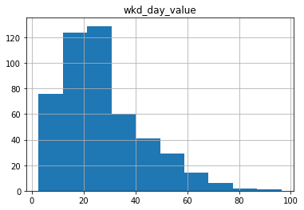

```python
ap.hist("wkd_day_value")
```

## E2

Given the pair-wise scatterplot for ap_road (below).

Variable explaination: road_class_2_i means primary road length in i m buffer. i = 50, 500, 5000 in this case. road_class_3_i means the same for local roads. wkd_day_value is the annual average NO2 measurements in $\mu g / m^3$, for daytime, weekdays.)

1. Describe what you observed and the information you obtained, in terms of correlations, value distributions, categorical variables.
2. Compare the results between figure 1 and figure 2 (in next chunk), give explainations of you observed differences.

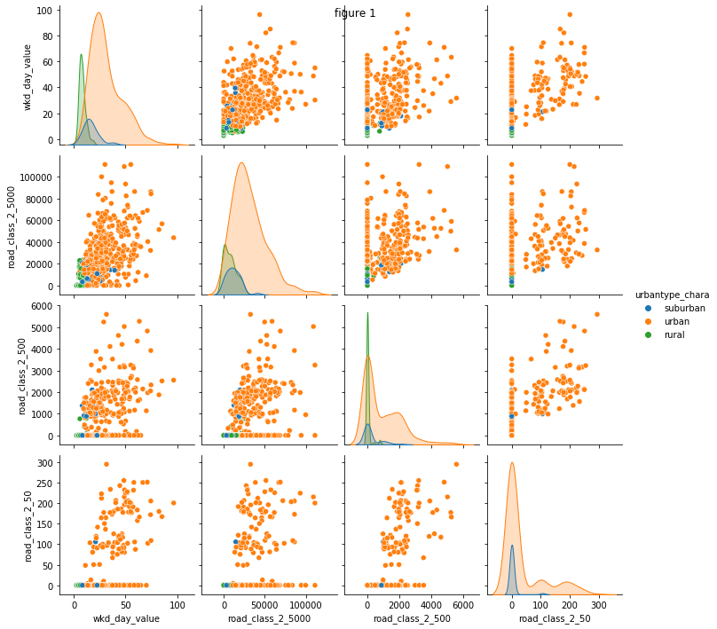

```python
ap_road1 = ap.filter (regex="road_class_2_50|wkd_day_value|urbantype_ch")
g=sns.pairplot(ap_road, hue = "urbantype_chara") # figure 1
g.fig.suptitle("figure 1")
```

[figure not shown]

```python
ap_road2 = ap.filter (regex="road_class_3_50|wkd_day_value|urbantype_ch")
g = sns.pairplot(ap_road, hue = "urbantype_chara") # figure 2
g.fig.suptitle("figure 2")
```